# Binary Outcomes

EC 325: Econometrics

Prof. Caraher

Colby College

2026-10-30

## Where We Are

- We’ve been building a regression toolkit all semester
- Started with bivariate OLS, added multiple regression, statistical inference
- Incorporated **qualitative information on the right-hand side**: dummy variables for categories, interaction effects for differential slopes
- Made our models more flexible: polynomials, logs, robust SEs

Today: what happens when the **left-hand side** — the dependent variable — is qualitative?

## Do Young Children Keep Women From Working?

The `mroz` data: **753 married women** in 1975. 57% were in the labor force.

**Predict:** how much less likely is a woman with one child under 6 to be in the labor force than a woman with none: 5, 20, or 40 percentage points?

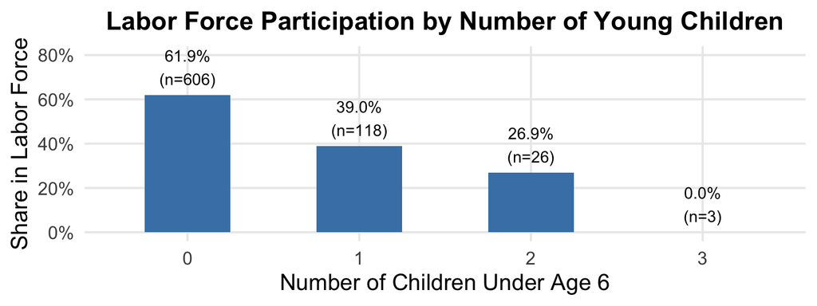

**23 points lower** (61.9% → 39.0%). The second child costs only 12 more (→ 26.9%). We’ll come back to that.

## When $y$ Is Binary, $\hat{y}$ Is a Probability

Labor force participation is a **binary** outcome: $y = 1$ if a woman is in the labor force, $y = 0$ if not.

What does $E(y \mid \mathbf{x})$ mean when $y$ can only be 0 or 1?

$$\begin{aligned}
E(y \mid \mathbf{x}) &= \textstyle\sum [\text{value} \times P(\text{value})] \\
&= 1 \times P(y = 1 \mid \mathbf{x}) + 0 \times P(y = 0 \mid \mathbf{x}) \\
&= P(y = 1 \mid \mathbf{x})
\end{aligned}$$

OLS estimates $E(y \mid \mathbf{x})$, so with a binary $y$ it estimates a **probability**.

With a binary dependent variable, $\hat{y}$ is the **predicted probability** that $y = 1$, given $\mathbf{x}$.

## The Linear Probability Model

Run OLS with a binary $y$. This is the **linear probability model** (LPM):

$$y = \beta_0 + \beta_1 x_1 + \beta_2 x_2 + \cdots + \beta_k x_k + \mu$$

$\hat{\beta}_j$ = the change in the **probability** that $y = 1$ for a one-unit increase in $x_j$, holding all else constant.

**Say “percentage points,” not “percent”**

If $\hat{\beta}_1 = -0.15$: “A one-unit increase in $x_1$ **decreases the probability** of $y = 1$ by **15 percentage points**.”

Going from 0.60 to 0.45 is a 15 **percentage point** decrease but a 25 **percent** decrease ($0.15 / 0.60 = 0.25$).

## Estimating the LPM

Back to `mroz`: what predicts whether a married woman is in the labor force?

- `inlf` = 1 if in the labor force, 0 otherwise
- `kidslt6` = number of children under age 6
- `kidsge6` = number of children aged 6–18
- `nwifeinc` = family income minus her earnings (thousands of $)
- `educ` = her years of education

```r
reg_lpm <- feols(inlf ~ kidslt6 + kidsge6 + nwifeinc + educ,
                 data = lf_data)
summary(reg_lpm)
```

```
OLS estimation, Dep. Var.: inlf
Observations: 753
Standard-errors: IID
             Estimate Std. Error   t value            Pr(>|t|)
(Intercept)  0.048495   0.095947  0.505429 0.61340672606837821
kidslt6     -0.225979   0.032730 -6.904348 0.00000000001077681 ***
kidsge6      0.014238   0.012950  1.099440 0.27192981889316054
nwifeinc    -0.007811   0.001520 -5.138243 0.00000035420719737 ***
educ         0.057914   0.007814  7.411772 0.00000000000033773 ***
---
Signif. codes:  0 '***' 0.001 '**' 0.01 '*' 0.05 '.' 0.1 ' ' 1
RMSE: 0.463985   Adj. R2: 0.117761
```

## Interpreting the Coefficients

### `kidslt6`: $\hat{\beta}_1 \approx -0.226$

Each additional child under 6 **decreases** the probability of being in the labor force by about 23 percentage points.

### `educ`: $\hat{\beta}_4 \approx 0.058$

Each additional year of education **increases** it by about 6 percentage points.

### `kidsge6`: $\hat{\beta}_2 \approx 0.014$

Older children have little effect: small and not statistically significant.

### `nwifeinc`: $\hat{\beta}_3 \approx -0.008$

Each additional $1,000 of other family income decreases it by about 0.8 percentage points.

The LPM is simple and intuitive, but it has **two problems**: built-in heteroskedasticity, and out-of-bounds predictions (below 0 or above 1).

## Problem 1: Built-In Heteroskedasticity

For a given $\mathbf{x}$, the error $\mu = y - p(\mathbf{x})$, where $p(\mathbf{x}) = E(y \mid \mathbf{x})$, can take only **two values**:

- If $y = 1$: $\;\mu = 1 - p(\mathbf{x})$, which happens with probability $p(\mathbf{x})$
- If $y = 0$: $\;\mu = -p(\mathbf{x})$, which happens with probability $1 - p(\mathbf{x})$

$$\text{Var}(\mu \mid \mathbf{x}) = p(\mathbf{x})\big[1 - p(\mathbf{x})\big]^2 + \big[1 - p(\mathbf{x})\big]\big[p(\mathbf{x})\big]^2 = p(\mathbf{x})\big(1 - p(\mathbf{x})\big)$$

The variance depends on $p(\mathbf{x})$, so it **changes with $\mathbf{x}$**. That’s heteroskedasticity by definition: Gauss-Markov assumption 5 fails.

It is largest at $p = 0.5$ and shrinks toward 0 and 1.

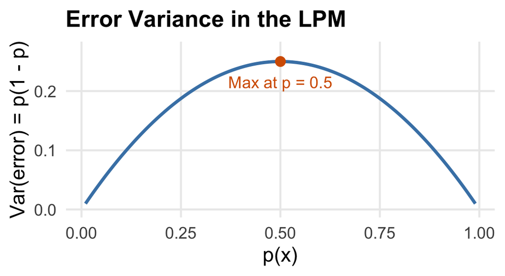

## Visualizing LPM Heteroskedasticity

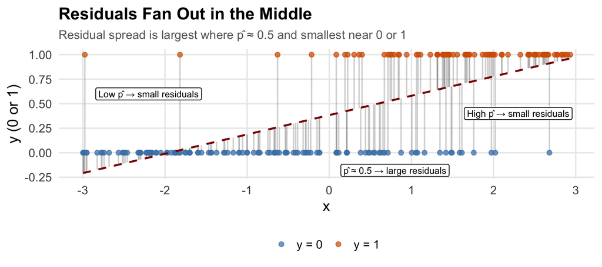

## The Fix: Robust Standard Errors

We already know the fix from Unit 9: `vcov = "HC1"`.

```r
lpm_robust <- feols(inlf ~ kidslt6 + kidsge6 + nwifeinc + educ,
                    vcov = "HC1", data = lf_data)
rbind(usual = se(reg_lpm), robust = se(lpm_robust)) |> round(4)
```

```
       (Intercept) kidslt6 kidsge6 nwifeinc   educ
usual       0.0959  0.0327  0.0129   0.0015 0.0078
robust      0.0937  0.0299  0.0135   0.0015 0.0072
```

- The $\hat{\beta}$s are the same. Here the SEs barely move (the one on `kidslt6` is 9% *smaller*), but you can’t know that in advance: **always use robust SEs with the LPM.**
- Problem 1: solved. On to Problem 2.

## Problem 2: Out-of-Bounds Predictions

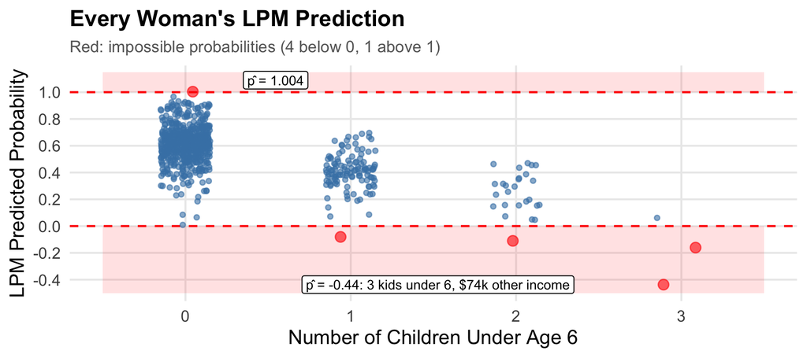

The LPM is a **straight line**, so extreme enough $\mathbf{x}$ values push it past 0 or 1. Here 5 of 753 women get impossible predictions, as low as -0.44. No SE fixes this: we need a different model.

## Logit: Bend the Line Into an S

**Logistic regression** (logit) wraps the linear index in a function $G(\cdot)$ that always stays between 0 and 1:

$$P(y = 1 \mid \mathbf{x}) = G(\beta_0 + \beta_1 x_1 + \cdots + \beta_k x_k), \qquad G(z) = \frac{\exp(z)}{1 + \exp(z)}$$

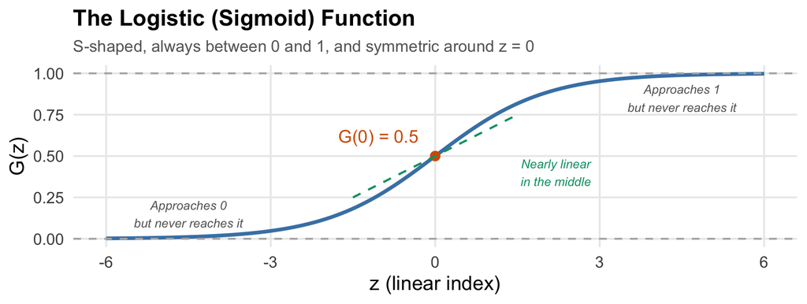

## Estimating Logit in R

$G(\cdot)$ is nonlinear, so we can’t use OLS. OLS minimizes $\sum(y_i - \hat{y}_i)^2$; **maximum likelihood** (MLE) instead picks the $\beta$s that make the observed data **most probable**: high $\hat{p}_i$ when $y_i = 1$, low $\hat{p}_i$ when $y_i = 0$.

```r
logit_reg <- feglm(inlf ~ kidslt6 + kidsge6 +
                     nwifeinc + educ,
                   family = binomial(link = "logit"),
                   data = lf_data)
```

|  | LPM (robust SEs) | Logit |
| --- | --- | --- |
| kidslt6 | -0.226*** | -1.087*** |
|  | (0.030) | (0.169) |
| kidsge6 | 0.014 | 0.067 |
|  | (0.014) | (0.060) |
| nwifeinc | -0.008*** | -0.039*** |
|  | (0.002) | (0.008) |
| educ | 0.058*** | 0.278*** |
|  | (0.007) | (0.040) |
| Num.Obs. | 753 | 753 |

* p < 0.1, ** p < 0.05, *** p < 0.01

- `feglm()` works like `feols()`; `family = binomial(link = "logit")` tells it to use the logistic function
- **Signs** match across the two models
- **Magnitudes** don’t: logit coefficients are on a different scale, the **log-odds**

## Logit Coefficients Are Log-Odds

In the LPM, $\hat{\beta}_j$ is the change in **probability**. In logit, it is the change in the **log-odds**.

The **odds** compare yes to no: $\;\text{Odds} = \frac{P(y = 1)}{1 - P(y = 1)}$. If $P = 0.75$, the odds are $0.75 / 0.25 = 3$ (“3 to 1 in favor”).

Logit is linear in the **log** of the odds:

$$\ln\left(\frac{P(y = 1 \mid \mathbf{x})}{1 - P(y = 1 \mid \mathbf{x})}\right) = \beta_0 + \beta_1 x_1 + \cdots + \beta_k x_k$$

Few people think in log-odds, so there are three ways to read a logit coefficient:

1. **Log-odds**: use the sign. Positive coefficients increase the probability; negative ones decrease it.
2. **Odds ratios**: exponentiate the coefficient.
3. **Marginal effects**: the change in probability, directly comparable to the LPM.

## Interpretation 2: Odds Ratios

The **odds ratio** $\exp(\hat{\beta}_j)$ is what a one-unit increase in $x_j$ multiplies the odds by.

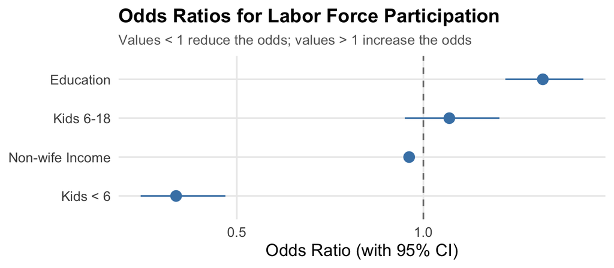

- **Kids < 6**: OR $\approx$ 0.34. Each young child multiplies the odds of being in the labor force by 0.34, cutting them by 66%.
- **Education**: OR $\approx$ 1.32. Each year of education raises the odds by 32%.

## Interpretation 3: Marginal Effects

In logit, the effect of $x_j$ on the probability **depends on where you start**. To compute it:

1. **Pick values** for all the $x$ variables and compute the **predicted probability**
2. **Increase $x_j$ by 1**, keeping everything else the same, and predict again
3. **Subtract**: marginal effect $= \hat{P}(y = 1 \mid x_j + 1) - \hat{P}(y = 1 \mid x_j)$

`predict()` does steps 1 and 2. Give it the fitted model and a `newdata` data frame with the $x$ values:

```r
predict(my_model, newdata = data.frame(x1 = 5, x2 = 10), type = "response")
```

- The column names in `newdata` must **exactly match** the variable names in the model
- **Always include `type = "response"`** so `predict()` returns a **probability**. Without it, some functions (like base R’s `glm()`) return the log-odds instead.

## Marginal Effects: Two Women

Woman A has **no children under 6**, one older child, $20k of other family income, and 12 years of education. What does **one young child** do?

```r
woman_a <- data.frame(kidslt6 = 0, kidsge6 = 1, nwifeinc = 20, educ = 12)
p0 <- predict(logit_reg, newdata = woman_a, type = "response")
p1 <- predict(logit_reg, newdata = woman_a |> mutate(kidslt6 = 1),
              type = "response")
p1 - p0
```

```
[1] -0.2646824
```

Woman B is identical except for **$50k** of other family income:

| Woman | Other income | P(in LF), 0 kids < 6 | P(in LF), 1 kid < 6 | Marginal effect |
| --- | --- | --- | --- | --- |
| A | $20k | 0.611 | 0.346 | -0.265 |
| B | $50k | 0.328 | 0.142 | -0.187 |

Same child, different effect: B starts lower on the S-curve, where it is flatter. As in any nonlinear model, the effect depends on where you start.

## Marginal Effect at the Mean

Which $x$ values should we report? A common choice is the **mean** of every explanatory variable.

```r
mean_data <- lf_data |>
    summarize(kidslt6 = mean(kidslt6), kidsge6 = mean(kidsge6),
              nwifeinc = mean(nwifeinc), educ = mean(educ))
p_mean  <- predict(logit_reg, newdata = mean_data, type = "response")
p_plus1 <- predict(logit_reg, newdata = mean_data |> mutate(kidslt6 = kidslt6 + 1),
                   type = "response")
p_plus1 - p_mean
```

```
[1] -0.261318
```

The LPM coefficient is -0.226: **close**, though not identical. A woman with average characteristics has a predicted probability of 0.57, near the middle of the S-curve, where it is nearly linear.

Near the center of the probability distribution, the LPM and logit produce **similar marginal effects**. They diverge mainly at the tails.

## LPM vs. Logit by Number of Young Children

Back to the opening question, with both models. Predicted probability of being in the labor force, with the other variables at their means:

| Children under 6 | LPM | Logit |
| --- | --- | --- |
| 0 | 62.2% | 63.4% |
| 1 | 39.6% | 36.9% |
| 2 | 17.0% | 16.5% |
| 3 | -5.6% | 6.2% |

- **LPM:** the same 22.6 points lower for every child, so 3 children gives a **negative** probability
- **Logit:** 26.5, then 20.4, then 10.3 points lower. The steps shrink as the S-curve flattens near 0, so it never goes below 0.

## Prediction vs. Causality

Which model fits depends on **the question you’re asking**.

### Causal question

*If $x$ changes, how does $P(y = 1)$ change?*

- Does a young child **cause** a woman to leave the labor force?
- A causal $\hat{\beta}$ comes from the **research design**, not from LPM vs. logit
- LPM: the effect directly, in percentage points

### Prediction question

*For this person, what is $P(y = 1)$?*

- Which loan applicants will **default**?
- Coefficients need not be causal; probabilities must be accurate
- Logit: predictions always between 0 and 1

Our LPM’s -0.23 on `kidslt6` is a **correlation**, not a clean causal effect: women with young children may differ in other ways that affect whether they work. Fixed effects, DiD, IV and RD (Units 11–15) are about getting causal effects.

## LPM or Logit?

|  | LPM | Logistic Regression |
| --- | --- | --- |
| **Shape** | Straight line: $P(y = 1) = \mathbf{x}\boldsymbol{\beta}$ | S-curve: $P(y = 1) = G(\mathbf{x}\boldsymbol{\beta})$ |
| **Estimation** | OLS | Maximum Likelihood |
| **Coefficients** | Change in probability | Change in log-odds |
| **Interpretation** | Direct and intuitive | Requires conversion (OR or ME) |
| **Predictions** | Can fall outside [0, 1] | Always in (0, 1) |
| **Heteroskedasticity** | Always present (use robust SEs) | Handled by MLE |
| **Common in** | Economics | Health sciences, epidemiology |
| **Best for** | Causal inference | Prediction |

- **Causal questions in economics:** the LPM is the workhorse. Most applied micro papers use it, sometimes with logit as a robustness check.
- **Health sciences, computer science, and other fields:** logit is the standard, usually reported as odds ratios.
- **Prediction, in every field:** logit wins, because its predictions are always valid probabilities.

## Summary

1. When $y$ is binary, $E(y \mid \mathbf{x}) = P(y = 1 \mid \mathbf{x})$
2. **LPM**: run OLS; $\hat{\beta}_j$ = change in probability (percentage points)
3. LPM problems: out-of-bounds predictions and always heteroskedastic (use robust SEs!)
4. **Logit**: wraps predictions in the logistic function; estimated by MLE
5. Logit coefficients = log-odds; convert via odds ratios or marginal effects
6. **Marginal effects at the mean** are the most practical way to compare logit to LPM
7. Near the center of the distribution, the two models typically **agree closely**

## Practice: Interpreting the LPM

Boston mortgage applications (`HMDA` data, `AER` package), estimated with an LPM and robust SEs:

|  | denied |
| --- | --- |
| (Intercept) | -0.091*** |
|  | (0.029) |
| black | 0.177*** |
|  | (0.025) |
| pirat | 0.559*** |
|  | (0.089) |
| Num.Obs. | 2380 |

* p < 0.1, ** p < 0.05, *** p < 0.01

- `denied` = 1 if the mortgage application was denied
- `black` = 1 if the applicant is Black
- `pirat` = monthly debt payments ÷ monthly income

**Q1.** Interpret the coefficient on `black`.

**Q2.** An applicant’s debt payments rise from 30% to 40% of monthly income (`pirat` rises by 0.10). How does the predicted probability of denial change?

1. Holding `pirat` constant, Black applicants were about 17.7 **percentage points** more likely to be denied than other applicants.
2. $0.10 \times 0.559 = 0.056$: the predicted probability of denial rises by about 5.6 **percentage points**.